# Daphnia kmer mutation study

Jullien Flynn

2017-01-12

**This is the final analysis for submission.** GC correction bins: [0, 0.25, 0.30, 0.35, 0.40, 0.45, 0.50, 0.55, 0.60, 0.75, 1.0]

Load necessary packages:

# Import data

```r
daphniakmers_normalized_w_techrep <- read.csv("~/Documents/FirstRotation-Andy/daphniakmers_corrected_bins3_Jan7.csv")

file_names <- as.vector(daphniakmers_normalized_w_techrep$X)
file_names <- sapply(strsplit(file_names, "\\."), '[', 1)
rownames(daphniakmers_normalized_w_techrep) <- file_names
# now get rid of the column that has the file name
daphniakmers_normalized_w_techrep[,1] <- NULL
# the columns (kmers) by their mean abundance
means <- colMeans(daphniakmers_normalized_w_techrep)
index.orders <- order(means, decreasing=T)
daphniakmers_normalized_w_techrep <- daphniakmers_normalized_w_techrep[,order(means, decreasing=T)]
# remove the total bp column and the poly-N columns
daphniakmers_normalized_w_techrep$total_bp <- NULL
daphniakmers_normalized_w_techrep$N.N <- NULL

## need to convert to matrix
daphniakmers_normalized_w_techrep <- as.matrix(daphniakmers_normalized_w_techrep)

# this is everything, with the technical replicates.

# remove the technical replicates from this analysis for now, will come back to them later.
# technical replicates are called C001 and C035 (from C01 and C35)
techreps <- c("C001", "C035")

daphniakmers_normalized <- daphniakmers_normalized_w_techrep[!rownames(daphniakmers_normalized_w_techrep) %in% techreps, ]
```

## Set the identities of the different samples

```r
MA1_names <- c("C01", "C02", "C03", "C06", "C07", "C08", "C12", "C13", "C14", "C16", "C17", "C18", "C20", "C21", "C24", "C25", "C34", "C35", "C36", "C37", "C38", "C39", "C40", "C44")
MA1_indexes <- match(MA1_names, rownames(daphniakmers_normalized))
MA2_names <- c("C23", "C27", "C43", "C49")
MA2_indexes <- match(MA2_names, rownames(daphniakmers_normalized))
Pop_names <- c("CC3", "CC4", "CC6", "CC7", "CC8", "CC9")
Pop_indexes <- match(Pop_names, rownames(daphniakmers_normalized))
```

# Description of kmers in Daphnia

## Get common kmers

Common kmers have a mean abundance of at least 100 copies across all lines.  
Perform a few summaries on the common kmers

```r
common.kmer.indexes <- c()
for (i in 1:ncol(daphniakmers_normalized)) {
  if (mean(daphniakmers_normalized[,i])>=100) {
    common.kmer.indexes <- c(common.kmer.indexes, i)
  }
}
names(common.kmer.indexes) <- colnames(daphniakmers_normalized)[common.kmer.indexes]
common.kmer.names <- colnames(daphniakmers_normalized)[common.kmer.indexes]


length(common.kmer.indexes) # number of total top kmers
```

```
## [1] 39
```

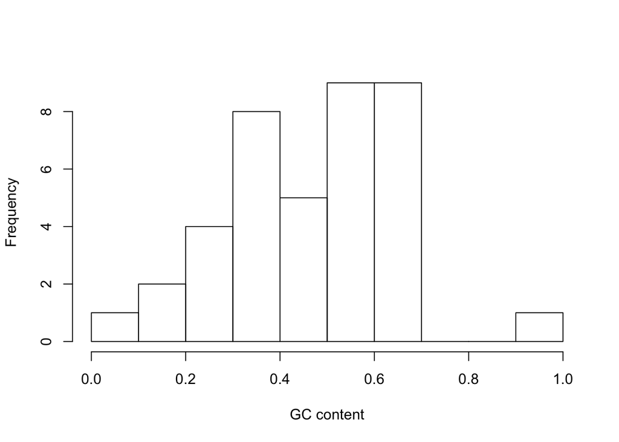

```r
# function that calculates the length of a kmer
Calc_kmer_length <- function (kmer_string) {
  return (nchar(kmer_string))
}
# calculate the lengths of the common kmers
common.kmer.lengths <- sapply(colnames(daphniakmers_normalized)[common.kmer.indexes], Calc_kmer_length)
names(common.kmer.lengths) <- colnames(daphniakmers_normalized)[common.kmer.indexes]

#kmers.to.add <- common.kmer.names[!common.kmer.names %in% common.kmer.names34] # these are kmers that weren't in the top 34
#common.kmer.names34 [! common.kmer.names34 %in% common.kmer.names] # these are kmers that are no longer in the top 39 but were in the top 34

Calc_GC_content <- function (kmer_string) {
  string <- BString(kmer_string)
  gc.content <- c(letterFrequency(string, letters=c("CG"), as.prob=F)/(length(string)))
  return(gc.content)
}
# calculate the GC content of the common kmers
common.kmer.GC <- sapply(colnames(daphniakmers_normalized)[common.kmer.indexes], Calc_GC_content)
names(common.kmer.GC) <- colnames(daphniakmers_normalized)[common.kmer.indexes]
# visualize the histogram
hist(common.kmer.GC, breaks=12, main="", xlab="GC content")
```

```r
# which kmers have at least 1000 copies?
kb.kmer.indexes <- c()
for (i in 1:ncol(daphniakmers_normalized)) {
  if (mean(daphniakmers_normalized[,i])>=1000) {
    kb.kmer.indexes <- c(kb.kmer.indexes, i)
  }
}
length(kb.kmer.indexes)
```

```
## [1] 12
```

```r
common.kmer.names[kb.kmer.indexes] # these are the super abundant kmers
```

```
##  [1] "A"                    "AACCT"                "ACGCCAGAGCACGCCAGTGC"
##  [4] "AATGG"                "AGG"                  "AACCTTGGCG"
##  [7] "AACAG"                "C"                    "ACGCCAGAGC"
## [10] "AAAAATAACAAC"         "AAG"                  "ACGCCAGTGC"
```

## Get the legit kmers

```r
# all the legit kmers
legit.kmer.indexes <- c()
for (i in 1:ncol(daphniakmers_normalized)) { ## go through each column of the data
  p <- daphniakmers_normalized[,i] >= 2 ## at least 2 copies
  if (sum(p)==nrow(daphniakmers_normalized)) { # if all samples have at least 10 copies
    legit.kmer.indexes <- c(legit.kmer.indexes, i)
  }
}
length(legit.kmer.indexes) # number of legit kmers
```

```
## [1] 162
```

```r
legit.kmer.names <- colnames(daphniakmers_normalized)[legit.kmer.indexes]
```

## Mean counts, length summary, absolute satDNA content

```r
# get the means of the common kmers
common.kmer.means <- colMeans(daphniakmers_normalized[,common.kmer.indexes])
common.kmer.means
```

```
##                    A                AACCT ACGCCAGAGCACGCCAGTGC
##           79528.0882           62281.3824           20047.8529
##                AATGG                  AGG           AACCTTGGCG
##           18852.9412            8501.0882            6892.1471
##                AACAG                    C           ACGCCAGAGC
##            6845.5000            6379.7353            3562.9706
##         AAAAATAACAAC                  AAG           ACGCCAGTGC
##            2187.5294            1791.8529            1718.7059
##               AGCCTG    AATCTGGAATGGAATGG        AAGCCAGTGCAGC
##             883.0000             785.7059             759.5882
##                 AAAG AAGAGCACGCCAGTGCACGC             AAAATAGG
##             708.2941             616.2941             531.0000
##                ACAGC                AAAAG                   AG
##             525.2647             470.7941             407.9706
##                AAGAG                 ATCC                  AAC
##             350.7941             336.9412             318.5294
##           ACAGGAGAGC                   AC               AAGGAG
##             288.9118             243.5588             230.9706
## AAGTGCACGCCAGAGCACGC           ACAGGAGACC    AAAAAGAAGATAGTAGG
##             216.4706             212.8235             199.8824
##               AACAAG              AAATAGG ACACCGAGGCTCCAGCTACT
##             195.8824             188.7647             137.9706
## AATGCACGCCAGAGCACGCC           AATGCACGCC ACACCGAGTCTCCAGCTACT
##             126.0000             124.0588             112.3235
##           AACGGTACGG                  ACT AATTCACACCAGAGCACGCC
##             110.8529             106.4118             104.0882
```

```r
# summary of the lengths
summary(as.factor(common.kmer.lengths))
```

```
##  1  2  3  4  5  6  7  8 10 12 13 17 20
##  2  2  4  2  6  3  1  1  7  1  1  2  7
```

```r
# Absolute kmer content
#use the "legit" to add up the entire kmer content across lines
kmers.abs <- matrix(nrow=nrow(daphniakmers_normalized), ncol=max(legit.kmer.indexes))
for (i in legit.kmer.indexes) {
  for (j in 1:nrow(daphniakmers_normalized)) {
    kmers.abs[j,i] <- daphniakmers_normalized[j,i] * (nchar(colnames(daphniakmers_normalized)[i], type="chars"))
  }
}
kmers.abs <- kmers.abs[,colSums(is.na(kmers.abs)) != nrow(kmers.abs)] # get rid of columns that are all NAs

total.kmers.abs <- c()
for (i in 1:nrow(kmers.abs)){
  total.kmers.abs[i] <- sum(kmers.abs[i,])/10^6
}
names(total.kmers.abs) <- rownames(daphniakmers_normalized)
# note these are in Mb
total.kmers.abs
```

```
##      C01      C02      C03      C06      C07      C08      C12      C13
## 1.011701 1.445189 1.078909 1.288937 1.055524 1.216688 1.410878 1.158469
##      C14      C16      C17      C18      C20      C21      C23      C24
## 1.113025 1.249561 1.256667 1.325667 1.667112 1.366363 1.248450 1.440856
##      C25      C27      C34      C35      C36      C37      C38      C39
## 1.369255 1.213874 1.623439 1.179734 1.190628 1.002873 1.275569 1.093022
##      C40      C43      C44      C49      CC3      CC4      CC6      CC7
## 1.418108 1.100263 1.160454 1.082031 1.046223 1.029877 1.122206 1.227378
##      CC8      CC9
## 0.969085 1.062354
```

```r
min(total.kmers.abs)
```

```
## [1] 0.969085
```

```r
max(total.kmers.abs)
```

```
## [1] 1.667112
```

```r
median(total.kmers.abs)
```

```
## [1] 1.202251
```

```r
# return to this later when comparing MA lines with population

# are there any kmers 15 bp long?
legit.kmer.lengths <- sapply(legit.kmer.names, Calc_kmer_length)
length(which(legit.kmer.lengths==15))
```

```
## [1] 13
```

```r
length(which(legit.kmer.lengths==5))
```

```
## [1] 10
```

```r
length(which(legit.kmer.lengths==10))
```

```
## [1] 15
```

```r
length(which(legit.kmer.lengths==20))
```

```
## [1] 50
```

```r
length(which(legit.kmer.lengths==12))
```

```
## [1] 19
```

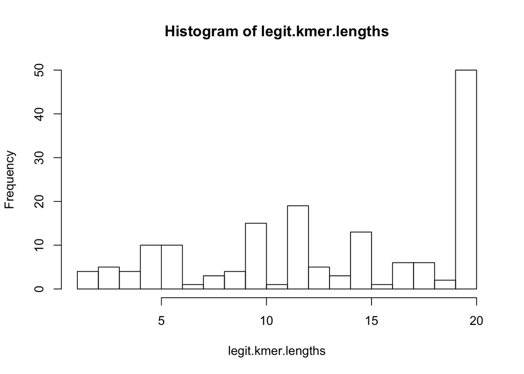

```r
hist(legit.kmer.lengths, breaks=20)
```

## Output the kmers into a supplementary table

```r
tableS1 <- data.frame(legit.kmer.names, colMeans(daphniakmers_normalized[,legit.kmer.indexes]))
#tableS1

#write.table(tableS1, file="~/Documents/FirstRotation-Andy/SuppTables/tableS1.txt" , quote=F, col.names=F, row.names=F, sep="\t")
```

## Figure 1

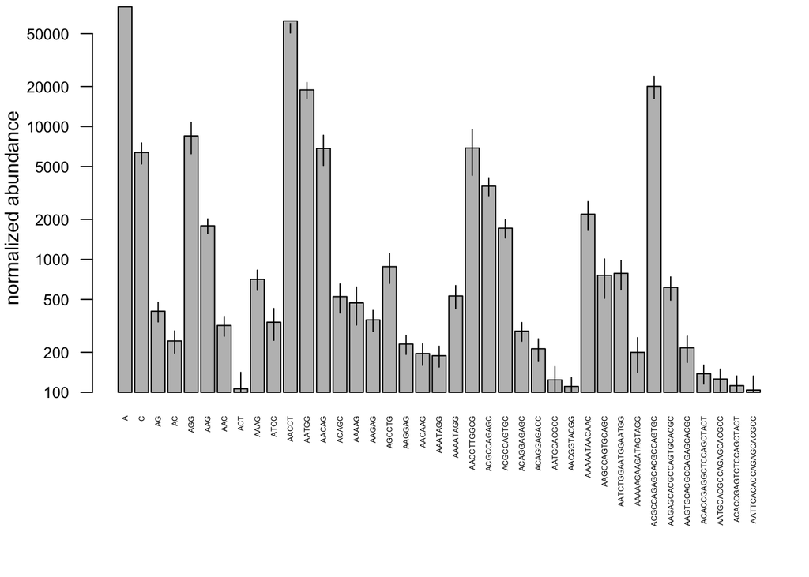

```r
common.kmer.sd <- apply(daphniakmers_normalized[,common.kmer.indexes], 2, sd)
kmer.table <- data.frame(common.kmer.names, common.kmer.means, common.kmer.lengths, common.kmer.sd)
ordered.kmer.table <- kmer.table[order(kmer.table$common.kmer.lengths),]
par(mar=c(8,4,1,1))
fig1 <- barplot(ordered.kmer.table$common.kmer.means, log="y", ylim=c(100,60000), names.arg=ordered.kmer.table$common.kmer.names, las=2, cex.names=0.4, cex.axis=0.8, ylab="normalized abundance", col="grey" )
arrows(x0=fig1, y0=(ordered.kmer.table$common.kmer.means-ordered.kmer.table$common.kmer.sd), x1=fig1, y1=ordered.kmer.table$common.kmer.means + ordered.kmer.table$common.kmer.sd, angle=90, code=3, length=0)
```

## Comparison to D. melanogaster Compare to what was found in Drosophila melanogaster Use kmers found in at least 100 copies in D. mel female (don’t want to have Y-specific kmers included) Use script : `compare_dmel.py` to get intersecting kmers between D. mel and D. pul.

```r
# import data
dmelkmers <- read.delim("~/Documents/FirstRotation-Andy/dmel.normalizedkmers.txt") # already normalized
# get the ones with at least 100 bp
dmel.common.indexes <- c()
for (i in 1:ncol(dmelkmers)) {
  if (dmelkmers[1,i]>=100) {
   dmel.common.indexes <- c(dmel.common.indexes, i)
  }
}

dmel.common.kmers <- names(dmelkmers)[dmel.common.indexes]
dmel.common.kmers <- dmel.common.kmers[2:length(dmel.common.kmers)]
#write(dmel.common.kmers, file="")

# Python script used to get all rotations of dmel kmers and see if they match to the D. pul kmers:

# Python script used to fund motifs in D. pul kmers and D. mel kmers:
```

# Mutation rates in the MA lines

Use the mean abundance of each kmer of the population as the ancestral state of the population

```r
MA.indexes <- c(1:28)
Pop.indexes <- c(29:34)
# make a new matrix
kmer.deviation <- matrix(nrow=nrow(daphniakmers_normalized), ncol=length(common.kmer.indexes))
for (i in common.kmer.indexes) {
  for (j in 1:nrow(daphniakmers_normalized)){
    kmer.deviation[j,i] <- daphniakmers_normalized[j,i] - mean(daphniakmers_normalized[Pop.indexes,i])
  }
}

colnames(kmer.deviation) <- common.kmer.names
rownames(kmer.deviation) <- rownames(daphniakmers_normalized)

generations_file <- read.table(file="~/Documents/FirstRotation-Andy/generations.txt", header=T)

generations <- as.vector(generations_file[,2])
names(generations) <- generations_file[,1]
```

## Kmer abundance means similar in MA lines as Population

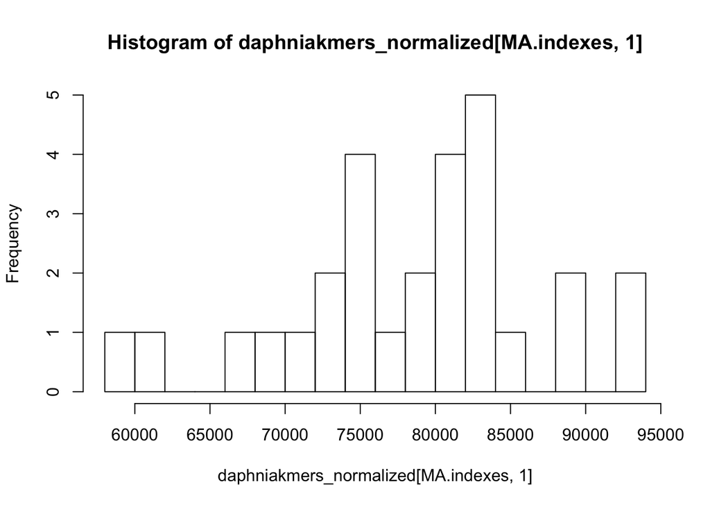

```r
MA.kmer.means <- colMeans(daphniakmers_normalized[MA.indexes, common.kmer.indexes])
Pop.kmer.means <- colMeans(daphniakmers_normalized[Pop.indexes, common.kmer.indexes])

hist(daphniakmers_normalized[MA.indexes, 1], breaks=12)
```

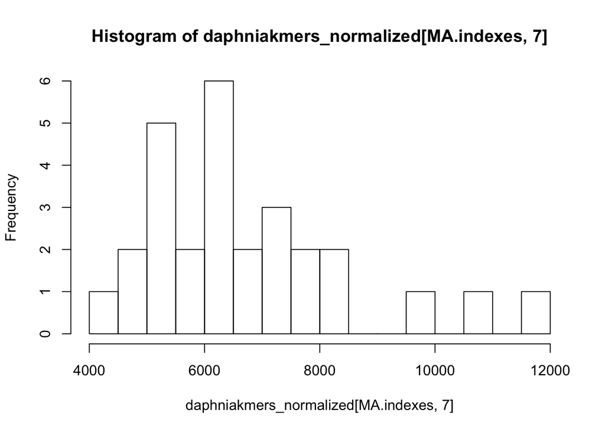

```r
hist(daphniakmers_normalized[MA.indexes, 7], breaks=12)
```

```r
MA.kmer.sd <- apply(daphniakmers_normalized[MA.indexes, common.kmer.indexes], 2, sd)

sum(Pop.kmer.means > MA.kmer.means + (2*MA.kmer.sd))
```

```
## [1] 0
```

```r
sum(Pop.kmer.means < MA.kmer.means - (2*MA.kmer.sd))
```

```
## [1] 0
```

```r
sum(Pop.kmer.means > MA.kmer.means + (1*MA.kmer.sd))
```

```
## [1] 3
```

```r
sum(Pop.kmer.means < MA.kmer.means - (1*MA.kmer.sd))
```

```
## [1] 9
```

```r
# 27/39 within 1 SD
# all within 2 SD

Pop.kmer.means < MA.kmer.means - (1*MA.kmer.sd)
```

```
##                    A                AACCT ACGCCAGAGCACGCCAGTGC
##                FALSE                 TRUE                FALSE
##                AATGG                  AGG           AACCTTGGCG
##                FALSE                 TRUE                FALSE
##                AACAG                    C           ACGCCAGAGC
##                FALSE                 TRUE                FALSE
##         AAAAATAACAAC                  AAG           ACGCCAGTGC
##                FALSE                FALSE                FALSE
##               AGCCTG    AATCTGGAATGGAATGG        AAGCCAGTGCAGC
##                 TRUE                FALSE                 TRUE
##                 AAAG AAGAGCACGCCAGTGCACGC             AAAATAGG
##                FALSE                FALSE                FALSE
##                ACAGC                AAAAG                   AG
##                FALSE                FALSE                FALSE
##                AAGAG                 ATCC                  AAC
##                 TRUE                FALSE                FALSE
##           ACAGGAGAGC                   AC               AAGGAG
##                FALSE                FALSE                FALSE
## AAGTGCACGCCAGAGCACGC           ACAGGAGACC    AAAAAGAAGATAGTAGG
##                 TRUE                FALSE                FALSE
##               AACAAG              AAATAGG ACACCGAGGCTCCAGCTACT
##                FALSE                FALSE                 TRUE
## AATGCACGCCAGAGCACGCC           AATGCACGCC ACACCGAGTCTCCAGCTACT
##                FALSE                FALSE                FALSE
##           AACGGTACGG                  ACT AATTCACACCAGAGCACGCC
##                 TRUE                FALSE                FALSE
```

## Box plot

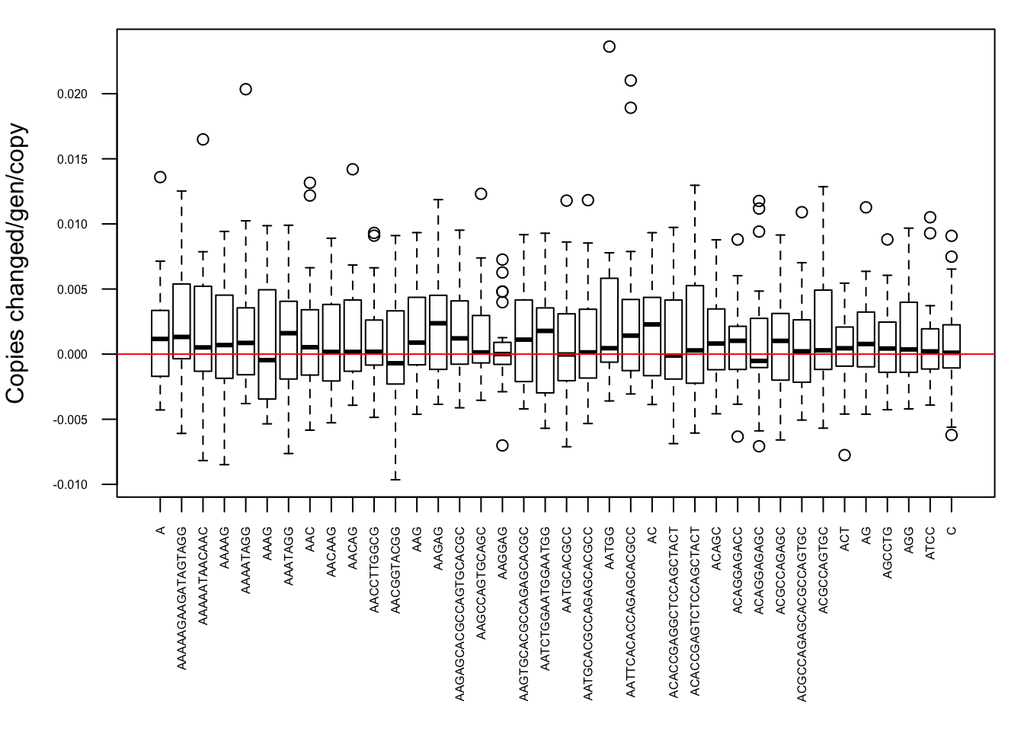

```r
#get in format for box plot, each MA line an observation
mutation.rate.data <- c()
mutation.kmer.indexes <- common.kmer.indexes[c(1,3:length(common.kmer.names))]
for (j in mutation.kmer.indexes) {
  for (i in MA.indexes) {
    mutation.rate.data <- c(mutation.rate.data, (kmer.deviation[i,j]/mean(daphniakmers_normalized[Pop.indexes,j])/generations[i]))
  }
}

mutation.df <- data.frame(mutation.rate.data, common.kmer.names[mutation.kmer.indexes])

par(mar=c(8,4,1,1))
boxplot (mutation.df[,1] ~ mutation.df[,2], data=mutation.df, las=2, cex.axis=0.5, ylab="Copies changed/gen/copy")
abline(h=0, col="red")
```

It seems more expansions than contractions  
Look across all kmers to see if this is indeed the case.  
## Expansions more common than contractions

```r
kmer.deviation.all <- matrix(nrow=nrow(daphniakmers_normalized), ncol=ncol(daphniakmers_normalized))
for (i in 1:ncol(daphniakmers_normalized)) {
  for (j in 1:nrow(daphniakmers_normalized)){
    kmer.deviation.all[j,i] <- daphniakmers_normalized[j,i] - mean(daphniakmers_normalized[Pop.indexes,i])
  }
}

colnames(kmer.deviation.all) <- colnames(daphniakmers_normalized)
rownames(kmer.deviation.all) <- rownames(daphniakmers_normalized)

mutation.rate.all <- matrix(ncol=ncol(kmer.deviation.all), nrow=length(MA.indexes))
for (j in legit.kmer.indexes) {
  for (i in MA.indexes) {
    mutation.rate.all[i,j] <- kmer.deviation.all[i,j]/mean(daphniakmers_normalized[Pop.indexes,j])/generations[i]
  }
}

mutation.rate.all <- mutation.rate.all[,colSums(is.na(mutation.rate.all)) != nrow(mutation.rate.all)]
colnames(mutation.rate.all) <- legit.kmer.names
rownames(mutation.rate.all) <- rownames(daphniakmers_normalized)[MA.indexes]

## now for each kmer, calcalate the average, the number of lines that expanded, and the number that contracted

mutation.rate.all.summary <- matrix(ncol=length(legit.kmer.indexes), nrow=3)
for (i in 1:ncol(mutation.rate.all)) {
  nexp <- 0
  ncontr <- 0
  avg <- mean(mutation.rate.all[,i])
  for (j in 1:nrow(mutation.rate.all)) {
    if (mutation.rate.all[j,i] > 0) {
      nexp <- nexp + 1
    } else {
      ncontr <- ncontr + 1
    }
  }
  mutation.rate.all.summary[1, i] <- avg
  mutation.rate.all.summary[2, i] <- nexp
  mutation.rate.all.summary[3, i] <- ncontr
}
colnames(mutation.rate.all.summary) <- legit.kmer.names
rownames(mutation.rate.all.summary) <- c("avg", "Nexp", "Ncontr")
mutation.rate.all.summary[,1:10]
```

```
##                   A        AACCT ACGCCAGAGCACGCCAGTGC        AATGG
## avg    -0.001024106  0.004046801          0.002121245 1.636898e-04
## Nexp    4.000000000 27.000000000         20.000000000 1.400000e+01
## Ncontr 24.000000000  1.000000000          8.000000000 1.400000e+01
##                 AGG   AACCTTGGCG        AACAG            C   ACGCCAGAGC
## avg     0.006633803  0.004538049 -0.001020879  0.004172247  0.001043985
## Nexp   23.000000000 19.000000000  8.000000000 24.000000000 18.000000000
## Ncontr  5.000000000  9.000000000 20.000000000  4.000000000 10.000000000
##        AAAAATAACAAC
## avg    -0.002279915
## Nexp    5.000000000
## Ncontr 23.000000000
```

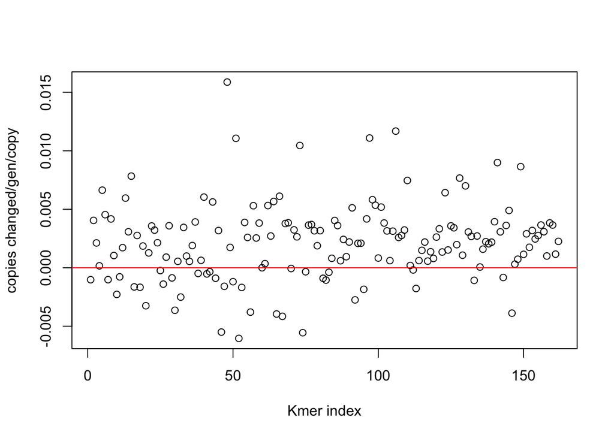

```r
plot(mutation.rate.all.summary[1,], xlab="Kmer index", ylab="copies changed/gen/copy")
abline(h=0, col="red")
```

```r
length(which(mutation.rate.all.summary[2,] > mutation.rate.all.summary[3,])) # 109 of 162 have more lines with expansions than contractions
```

```
## [1] 109
```

```r
length(which(mutation.rate.all.summary[2,] < mutation.rate.all.summary[3,])) # 46 have more MA lines with contractions than MA lines with expansions
```

```
## [1] 46
```

```r
length(which(mutation.rate.all.summary[1,] > 0)) # 124 of 162 have overall average expansion
```

```
## [1] 124
```

## Calculate overall mutation rates per kmer

```r
kmer.deviation.abs <- abs(kmer.deviation)
mean_generations <- mean(generations)
# sum all the numbers of copy changes and average
mutation.rate.abs <- colMeans(kmer.deviation.abs[MA.indexes, mutation.kmer.indexes])/mean_generations
sort(mutation.rate.abs, decreasing=T)
```

```
##                    A ACGCCAGAGCACGCCAGTGC                  AGG
##          105.4607928           43.6480035           42.5846354
##           AACCTTGGCG                AATGG                    C
##           29.0079572           25.7795139           21.9885706
##                AACAG         AAAAATAACAAC           ACGCCAGAGC
##           19.1809896            7.3081597            5.9450231
##        AAGCCAGTGCAGC               AGCCTG           ACGCCAGTGC
##            3.9670139            3.7212095            3.2225116
##                  AAG    AATCTGGAATGGAATGG                AAAAG
##            2.7226562            2.3168403            2.3004919
##                 AAAG AAGAGCACGCCAGTGCACGC             AAAATAGG
##            1.6757812            1.4956597            1.4395255
##                ACAGC                 ATCC                AAGAG
##            1.2980324            1.2207755            1.0774016
##    AAAAAGAAGATAGTAGG                   AG                  AAC
##            0.9690394            0.7695312            0.7008102
## AAGTGCACGCCAGAGCACGC              AAATAGG                   AC
##            0.6539352            0.6145833            0.5360243
##           ACAGGAGAGC           ACAGGAGACC ACACCGAGGCTCCAGCTACT
##            0.4545718            0.4432870            0.3864294
##                  ACT               AAGGAG               AACAAG
##            0.3816551            0.3705150            0.3524306
##           AATGCACGCC           AACGGTACGG AATTCACACCAGAGCACGCC
##            0.3498264            0.3430266            0.2949942
## ACACCGAGTCTCCAGCTACT AATGCACGCCAGAGCACGCC
##            0.2569444            0.2447917
```

```r
median(mutation.rate.abs)
```

```
## [1] 1.259404
```

```r
mean(mutation.rate.abs)
```

```
## [1] 8.828525
```

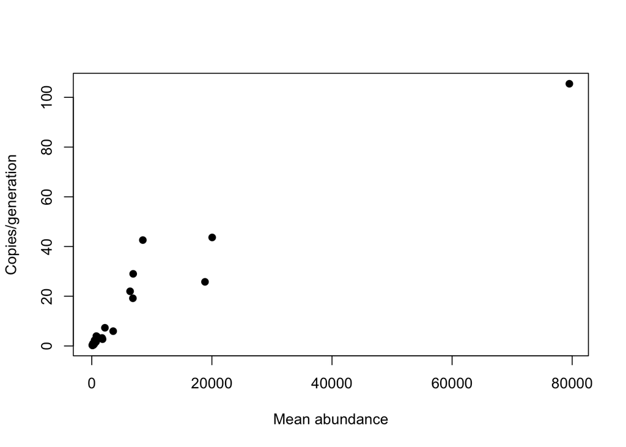

```r
# see if correlation with kmer abundance
plot(y=mutation.rate.abs, x=common.kmer.means[mutation.kmer.indexes], pch=19,  xlab="Mean abundance", ylab="Copies/generation")
```

```r
# seems to be linear relationship, check statistical significance
summary(lm(formula = mutation.rate.abs ~ common.kmer.means[mutation.kmer.indexes]))
```

```
##
## Call:
## lm(formula = mutation.rate.abs ~ common.kmer.means[mutation.kmer.indexes])
##
## Residuals:
##    Min     1Q Median     3Q    Max
## -8.015 -2.582 -2.302 -1.598 27.988
##
## Coefficients:
##                                           Estimate Std. Error t value
## (Intercept)                              2.762e+00  1.145e+00   2.413
## common.kmer.means[mutation.kmer.indexes] 1.392e-03  8.248e-05  16.878
##                                          Pr(>|t|)
## (Intercept)                                0.0211 *
## common.kmer.means[mutation.kmer.indexes]   <2e-16 ***
## ---
## Signif. codes:  0 '***' 0.001 '**' 0.01 '*' 0.05 '.' 0.1 ' ' 1
##
## Residual standard error: 6.699 on 36 degrees of freedom
## Multiple R-squared:  0.8878, Adjusted R-squared:  0.8847
## F-statistic: 284.9 on 1 and 36 DF,  p-value: < 2.2e-16
```

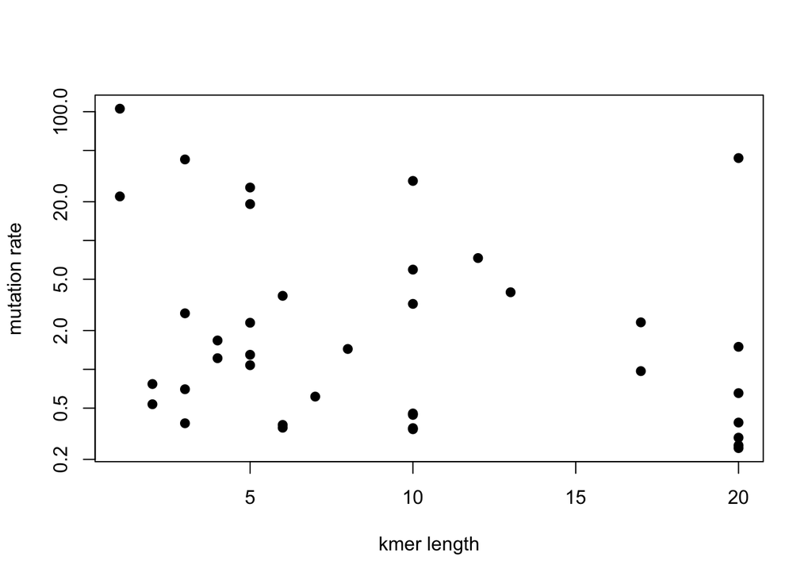

```r
# no relationship with kmer length
plot(y=mutation.rate.abs, x=common.kmer.lengths[mutation.kmer.indexes], log="y", xlab="kmer length", ylab="mutation rate", pch=19)
```

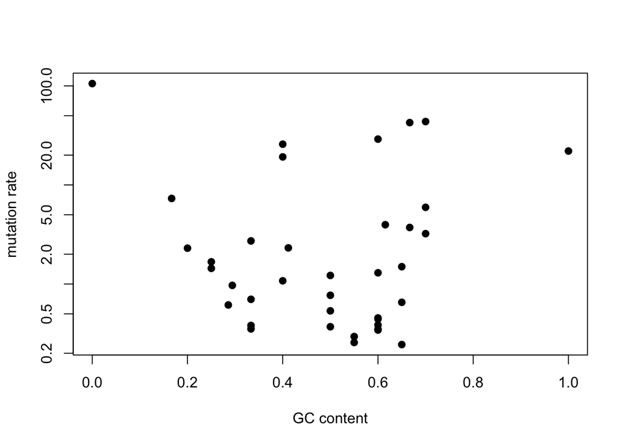

```r
# no relationship with GC content
plot(y=mutation.rate.abs, x=common.kmer.GC[mutation.kmer.indexes], log="y", xlab="GC content", ylab="mutation rate", pch=19)
```

```r
# What about the telomere?
telomere.change.rate <- mean(kmer.deviation.abs[MA.indexes, 2])/mean_generations
mean(daphniakmers_normalized[MA.indexes,2])
```

```
## [1] 65147.61
```

```r
mean(daphniakmers_normalized[Pop.indexes,2])
```

```
## [1] 48905.67
```

## Normalize the mutation rate by the kmer abundance

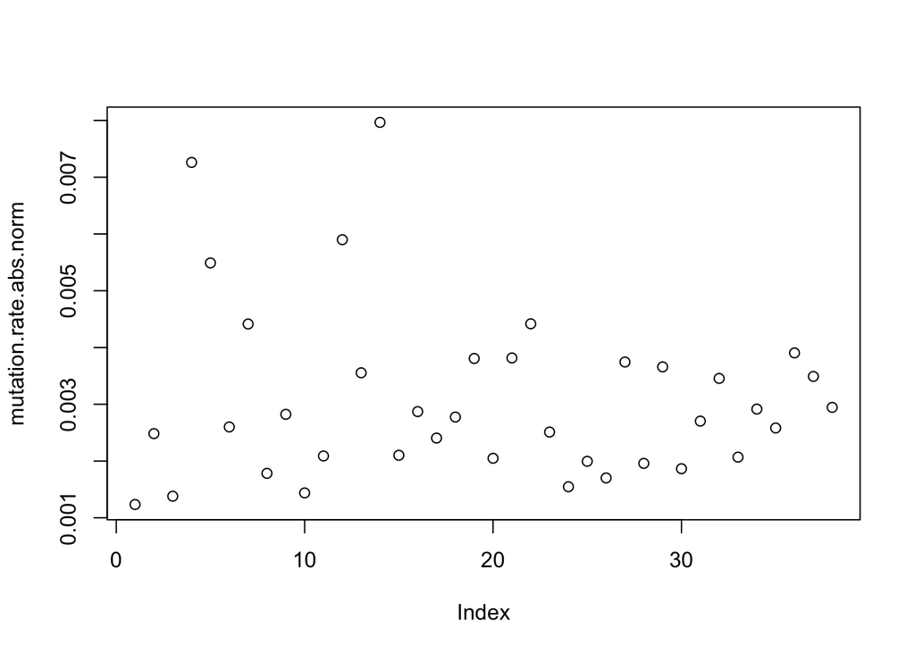

```r
initial_means <- c()
for (j in common.kmer.indexes) {
  initial_means <- c(initial_means, mean(daphniakmers_normalized[Pop.indexes,j]) )
}
names(initial_means) <- colnames(kmer.deviation)

mutation.rate.abs.norm <- colMeans(kmer.deviation.abs[MA.indexes,mutation.kmer.indexes])/(mean_generations*initial_means[mutation.kmer.indexes])
plot(mutation.rate.abs.norm)
```

```r
# come back to plot this when comparing to the Population isolates
mean(mutation.rate.abs.norm)
```

```
## [1] 0.003097427
```

```r
median(mutation.rate.abs.norm)
```

```
## [1] 0.002739004
```

```r
which(mutation.rate.abs.norm == max(mutation.rate.abs.norm))
```

```
## AAGCCAGTGCAGC
##            14
```

```r
min(mutation.rate.abs.norm)
```

```
## [1] 0.001234321
```

```r
max(mutation.rate.abs.norm)
```

```
## [1] 0.007965891
```

```r
# come back to plot this when comparing to the Population isolates
```

## Output mutation rate into supplementary tables

```r
#Table SX - mutation rates per kmer
#write.table()
```

## Kmers generated de novo

Search for kmers that are present in 1-2 MA lines but no others.  
First make a new matrix with all kmers that are present in at least 1 normalized copy in at least 1 MA line

```r
daphniakmers.all <- as.matrix(daphniakmers_normalized[,common.kmer.indexes]) # start with small matrix and add to it
for (i in (max(common.kmer.indexes)+1):ncol(daphniakmers_normalized)){ ## go through all columns in data
  counter <- 0
  for (j in 1:nrow(daphniakmers_normalized)) {
    if (daphniakmers_normalized[j,i] > 2 ) {
      counter <- counter + 1
    }
  }
  if (counter > 0) { ## if there is at least one sample with 2 copies of this kmer, add it to the new matrix
    daphniakmers.all <- cbind(daphniakmers.all[, , drop=FALSE], daphniakmers_normalized[,i, drop=FALSE])
  }
}
ncol(daphniakmers.all) # all kmers that have at least one line with 3 copies normalized.
```

```
## [1] 398
```

### Get the new kmers

```r
get_new_kmers <- function (nlines) {
  kmers.new <- matrix(nrow=nrow(daphniakmers.all)) # make new empty matrix
  for (i in 1:ncol(daphniakmers.all)) { ## go through each column of the data
    uniq <- daphniakmers.all[,i] > 0 # uniq will be true and false
    if (sum(uniq)==nlines) { # if only there are nlines true elements, add to matrix
      kmers.new <- cbind(kmers.new[, , drop=FALSE], daphniakmers.all[,i, drop=FALSE])
    }
  }
  kmers.new <- kmers.new[,2:ncol(kmers.new)] # remove first column, which is all NA
  return(kmers.new)
}

new_kmers_unique <- get_new_kmers(1)
new_kmers_unique
```

```
##     AAACCCTAGTGGGTTGT ACCAG AAATG ACAT AAGCCACGC
## C01                 0     0     0    0         0
## C02                14    11     0    0         3
## C03                 0     0     0    0         0
## C06                 0     0     0    0         0
## C07                 0     0     0    0         0
## C08                 0     0     0    0         0
## C12                 0     0     0    0         0
## C13                 0     0     0    0         0
## C14                 0     0     0    0         0
## C16                 0     0     0    0         0
## C17                 0     0     0    0         0
## C18                 0     0     4    0         0
## C20                 0     0     0    0         0
## C21                 0     0     0    0         0
## C23                 0     0     0    0         0
## C24                 0     0     0    0         0
## C25                 0     0     0    0         0
## C27                 0     0     0    0         0
## C34                 0     0     0    0         0
## C35                 0     0     0    3         0
## C36                 0     0     0    0         0
## C37                 0     0     0    0         0
## C38                 0     0     0    0         0
## C39                 0     0     0    0         0
## C40                 0     0     0    0         0
## C43                 0     0     0    0         0
## C44                 0     0     0    0         0
## C49                 0     0     0    0         0
## CC3                 0     0     0    0         0
## CC4                 0     0     0    0         0
## CC6                 0     0     0    0         0
## CC7                 0     0     0    0         0
## CC8                 0     0     0    0         0
## CC9                 0     0     0    0         0
```

```r
colnames(new_kmers_unique)
```

```
## [1] "AAACCCTAGTGGGTTGT" "ACCAG"             "AAATG"
## [4] "ACAT"              "AAGCCACGC"
```

```r
new_kmers_pairs <- get_new_kmers(2)
colnames(new_kmers_pairs)
```

```
## [1] "AATG"    "AAACT"   "AGAT"    "ACCCT"   "AAAAGGT"
```

```r
new_kmers_pairs
```

```
##     AATG AAACT AGAT ACCCT AAAAGGT
## C01    0     0    0     0       0
## C02    0     0    0     0       0
## C03    0     0    0     0       0
## C06    0     0    0     0       0
## C07    0     0    0     0       0
## C08    0     0    0     0       0
## C12    3     0    0     0       0
## C13    0     2    0     0       0
## C14    0     0    0     0       0
## C16    0     0    0     3       0
## C17    0     0    0     0       0
## C18    0     0    0     0       0
## C20    0     0    3     0       0
## C21    0     3    0     0       0
## C23    0     0    0     0       0
## C24    0     0    0     0       0
## C25    0     0    0     0       0
## C27    0     0    0     0       0
## C34    5     0    0     0       0
## C35    0     0    0     0       0
## C36    0     0    0     0       0
## C37    0     0    0     0       0
## C38    0     0    0     0       0
## C39    0     0    0     0       0
## C40    0     0    0     0       0
## C43    0     0    0     0       1
## C44    0     0    0     0       0
## C49    0     0    0     0       0
## CC3    0     0    0     0       3
## CC4    0     0    0     0       0
## CC6    0     0    0     0       0
## CC7    0     0    0     0       0
## CC8    0     0    2     1       0
## CC9    0     0    0     0       0
```

## Get the mean abundance of the similar kmer

```r
similar_kmers <- c("AATGG", "AAAAG", "AACAG", "AACCT", "AAAG", "AAGG", "AAAG")

similar_kmer_abundances <- c()
for (i in 1:length(similar_kmers)) {
  index <- which(legit.kmer.names == similar_kmers[i])
  abun <- mean(daphniakmers_normalized[,index])
  similar_kmer_abundances <- c(similar_kmer_abundances, abun)
}
names(similar_kmer_abundances) <- similar_kmers

similar_kmer_abundances
```

```
##       AATGG       AAAAG       AACAG       AACCT        AAAG        AAGG
## 18852.94118   470.79412  6845.50000 62281.38235   708.29412    11.14706
##        AAAG
##   708.29412
```

```r
which(colnames(daphniakmers_normalized)=="ACAACCCACTAGGGTTT")
```

```
## integer(0)
```

### Quality control - look for kmers unique to library prep

No kmers are unique to one library prep.

```r
get_lib2_uniq_kmers <- function (indexes_to_include, indexes_to_exclude) {
  kmers.uniq <- matrix(nrow=34)
  for (i in 1:ncol(daphniakmers.all)) { ## go through each column of the data
    uniq <- daphniakmers.all[indexes_to_include,i] > 0 # gives vector of true and falses
    absent <- daphniakmers.all[indexes_to_exclude, i] == 0
    if (sum(uniq)==6 & sum(absent)==28) {
      kmers.uniq <- cbind(kmers.uniq[, , drop=FALSE], daphniakmers.all[,i, drop=FALSE])
    }
  }
  if (ncol(kmers.uniq)<2) {
    return ("none")
  } else {
    return(kmers.uniq)
    }
}
lib1.indexes <- MA1_indexes
lib2.indexes <- c(MA2_indexes, Pop_indexes)
get_lib2_uniq_kmers(lib2.indexes, lib1.indexes)
```

```
## [1] "none"
```

```r
get_lib2_uniq_kmers(lib1.indexes, lib2.indexes)
```

```
## [1] "none"
```

## Look for kmers LOST de novo

```r
# function returns the kmers lost in n lines
get_kmers_lost <- function (nlines) {
  kmers.lost <- matrix(nrow=34)
  for (i in 1:ncol(daphniakmers.all)) { ## go through each column of the data
    l <- daphniakmers.all[,i] == 0  ## 0 copies
    p <- daphniakmers.all[,i] > 1 ## present
    if (sum(l)==nlines && sum(p)==(34-nlines)) { # if there is only nlines line with 0 copies, and all others are present
      kmers.lost <- cbind(kmers.lost[, , drop=FALSE], daphniakmers.all[,i, drop=FALSE])
    }
  }
  kmers.lost <- kmers.lost[,2:ncol(kmers.lost)] # first column is NA
}

kmers_lost_uniq <- get_kmers_lost(1)
ncol(kmers_lost_uniq)
```

```
## [1] 7
```

```r
kmers_lost_uniq
```

```
##     AAGGAATGG AAAAAGAAGGAGATAG AATAG ACGCCCGAGC AATCT ACACCGACCACTACT
## C01        43               14    12          5    11               5
## C02        95               79     4         20     3               5
## C03        53               46    24          8     4               8
## C06        66                2     9         10     2               5
## C07        67               85    18          8     5               7
## C08        60               43    10         14     8               2
## C12       101               44     9         18     2               8
## C13        72               58     9         13     5               5
## C14        58               15    20          8     7               4
## C16        39               68    10         13     9               7
## C17        77               73     7         10     7               4
## C18        60               51    12         21    10              13
## C20        78               95     7         31     0              14
## C21        55               12    14         13     5               4
## C23        38               42    49         14     4               6
## C24        79               79     3         25     8               3
## C25        83               37     0         21     6               9
## C27        34               16    24         15     5               4
## C34        95               50    10         17     3               6
## C35        75               62     8         16    12               3
## C36        79                0    12         13     7               4
## C37        58               60     5         14     3               7
## C38        81               32    16          8     2               6
## C39        49               31    15         11     6               4
## C40         0               62     6          0     8               0
## C43        45               54    28         13     9               3
## C44        72               78     4         18     6               2
## C49        54               24    14          9     8               4
## CC3        49               48    29          9    17               6
## CC4        35               25    38         10     4               7
## CC6        37               33    30         15    11               7
## CC7        47               24    31         19     9               3
## CC8        46               55    15          8    15               5
## CC9        54               74    35          8    15               4
##     AAAGGCAACAACAGT
## C01               3
## C02               2
## C03               3
## C06               3
```

[output cut: 15 more lines]

```
## C35               0
## C36               6
## C37               4
## C38               2
## C39               5
## C40               7
## C43               4
## C44               2
## C49               4
## CC3               4
## CC4               4
## CC6               4
## CC7               3
## CC8               2
## CC9               6
```

```r
kmers_lost_pairs <- get_kmers_lost(2)
ncol(kmers_lost_pairs)
```

```
## [1] 2
```

```r
kmers_lost_pairs
```

```
##     AATGT AAAAAAAC
## C01    26        7
## C02     0        8
## C03    13        8
## C06    13        9
## C07    15       13
## C08    10       17
## C12    13        8
## C13    11        4
## C14    13        6
## C16    18       10
## C17    21       14
## C18    12       15
## C20     4        2
## C21     6        8
## C23    13       13
## C24     4        3
## C25     7        4
## C27    24        6
## C34     0        4
## C35     4        4
## C36     6        6
## C37     6        5
## C38    12        5
## C39    18        0
## C40     7        2
## C43    18       10
## C44     4        0
## C49     6        7
## CC3    12        6
## CC4    19        7
## CC6    15        6
## CC7    17       10
## CC8    16        8
## CC9    14        6
```

```r
# for lost kmers, calculate the mean in the other lines
Calc_lost_other_means <- function (table) {
  other_means <- c()
  for (i in 1:ncol(table)) {
  other_means <- c(other_means, mean(table[which(table[,i]>0),i]))
  }
  return(other_means)
}
Calc_lost_other_means(kmers_lost_uniq)
```

```
## [1] 61.636364 47.606061 16.272727 13.787879  7.151515  5.575758  4.181818
```

```r
Calc_lost_other_means(kmers_lost_pairs)
```

```
## [1] 12.40625  7.53125
```

# Compare MA lines with population

## Compare the total satDNA content

```r
min(total.kmers.abs[MA.indexes])
```

```
## [1] 1.002873
```

```r
min(total.kmers.abs[Pop.indexes])
```

```
## [1] 0.969085
```

```r
max(total.kmers.abs[MA.indexes])
```

```
## [1] 1.667112
```

```r
max(total.kmers.abs[Pop.indexes])
```

```
## [1] 1.227378
```

```r
median(total.kmers.abs[MA.indexes])
```

```
## [1] 1.232569
```

```r
median(total.kmers.abs[Pop.indexes])
```

```
## [1] 1.054288
```

```r
max(total.kmers.abs[MA.indexes])/min(total.kmers.abs[MA.indexes])
```

```
## [1] 1.662336
```

```r
# MA lines diverged by a factor of 1.66

max(total.kmers.abs[Pop.indexes])/min(total.kmers.abs[Pop.indexes])
```

```
## [1] 1.266533
```

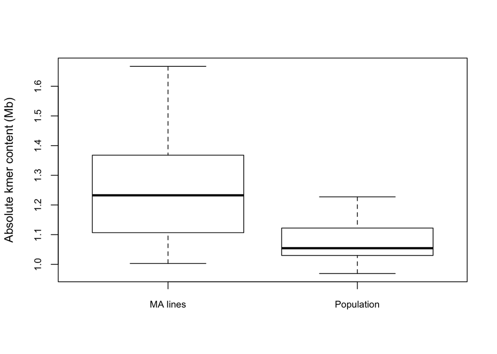

```r
# Population isolates diverged by only factor of 1.27

## make a box plot of this.
vals <- c(total.kmers.abs[MA.indexes], total.kmers.abs[Pop.indexes])
cat <- c( rep("MA lines", times=28), rep("Population", times=6))
kmers.abs.df <- data.frame(vals, cat)
boxplot (kmers.abs.df[,1] ~ kmers.abs.df[,2], data=kmers.abs.df, cex.axis=0.8, ylab="Absolute kmer content (Mb)")
```

```r
# not a significant difference based on the Levene's test

groups <- as.factor(c(rep(1, times=28), rep(2, times=6)))
leveneTest(total.kmers.abs, groups, center=median)
```

```
## Levene's Test for Homogeneity of Variance (center = median)
##       Df F value Pr(>F)
## group  1  2.5839 0.1178
##       32
```